# Gaussian Mixture Model & EM

WP8

Marc Florian

2018-12-07 09:20:07

# Libraries included

```r
library(knitr)
library(mclust)
library(NMF) #for purity testing on clusters
```

## Seed

```r
set.seed(702828)
```

# EM using `mclust`

## EM vs. *$k$*-means

**1.** First, we’ll import the data

```r
data1 <- read.csv("data1.csv", sep = ",", header = TRUE)
data2 <- read.csv("data2.csv", sep = ",", header = TRUE)
```

Let’s plot all of this.

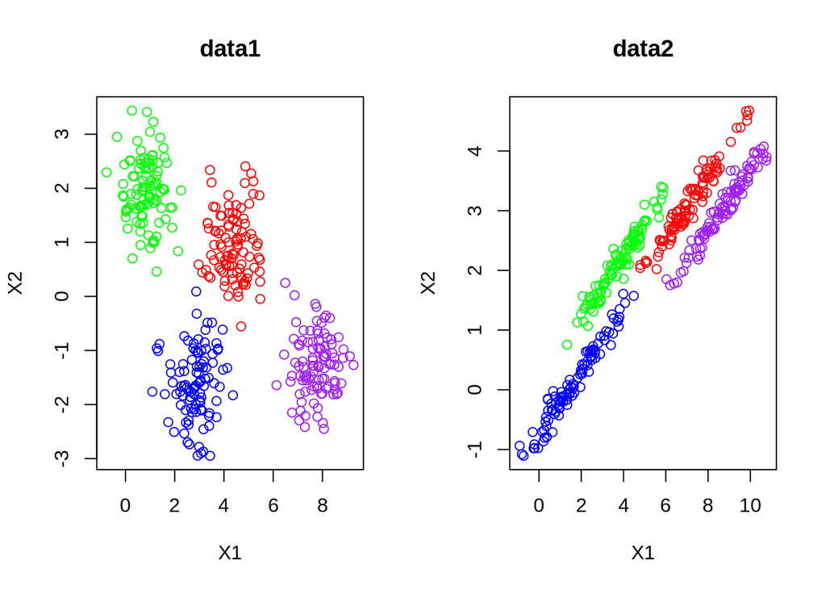

```r
par(mfrow = c(1, 2))
plot(data1$X1, data1$X2, col=c("red", "green", "blue", "purple")[data1$truth], xlab = "X1", ylab = "X2", main = "data1")
plot(data2$X1, data2$X2, col=c("red", "green", "blue", "purple")[data2$truth], xlab = "X1", ylab = "X2", main = "data2")
```

**2.** Now let’s apply a k-means clustering on both datasets. There will be 4 clusters on each and twenty iterations on the k-means algorithm *top*.

```r
km.data1 = kmeans(data1[,1:2], 4, iter.max = 20)
km.data2 = kmeans(data2[,1:2], 4, iter.max = 20)
```

We can plot the dataset again with colors according to the k-means clusters.

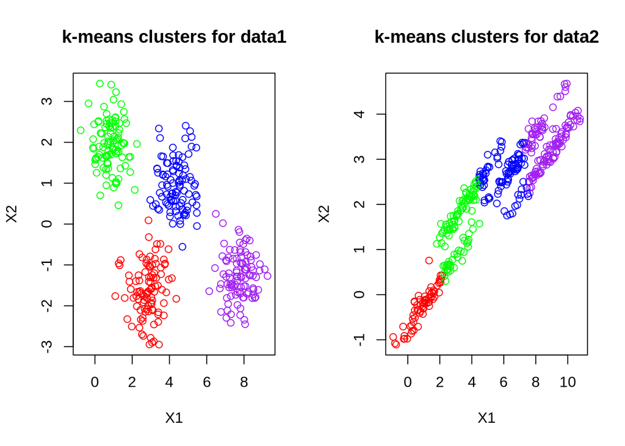

```r
par(mfrow = c(1, 2))
plot(data1$X1, data1$X2, col=c("red", "green", "blue", "purple")[km.data1$cluster], xlab = "X1", ylab = "X2", main = "k-means clusters for data1")
plot(data2$X1, data2$X2, col=c("red", "green", "blue", "purple")[km.data2$cluster], xlab = "X1", ylab = "X2", main = "k-means clusters for data2")
```

Because the k-means is based on distance from a center, it shows fair results with dense “circled-shaped” data clusters. Therefore, the clustering method show poor results on the second dataset.

**3.** We’ll be fitting a GMM (Gaussian Mixture Model) on the datasets with the `mclust` library. To begin with, we should compute the *Bayesian Information Criterion* (BIC).

```r
BIC.data1 <- mclustBIC(data1[,1:2])
BIC.data2 <- mclustBIC(data2[,1:2])
GMM.data1 <- Mclust(data1[,1:2], x = BIC.data1)
GMM.data2 <- Mclust(data2[,1:2], x = BIC.data2)
```

Now for the plot:

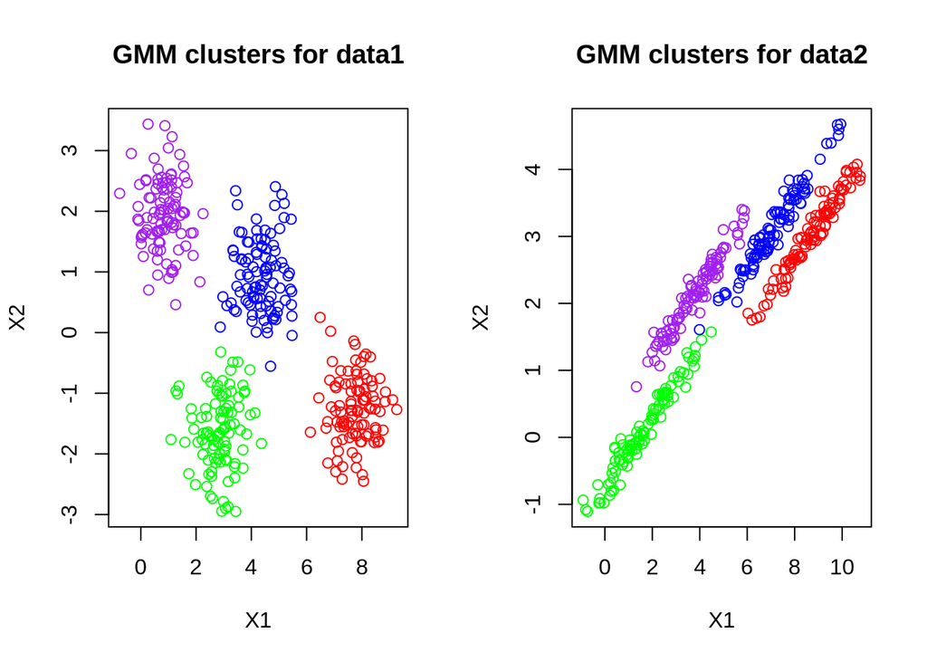

```r
par(mfrow = c(1, 2))
plot(data1$X1, data1$X2, col=c("red", "green", "blue", "purple")[GMM.data1$classification], xlab = "X1", ylab = "X2", main = "GMM clusters for data1")
plot(data2$X1, data2$X2, col=c("red", "green", "blue", "purple")[GMM.data2$classification], xlab = "X1", ylab = "X2", main = "GMM clusters for data2")
```

GMM clustering shows great performances on both datasets. With the neaked eye, it even seems that there’s only one data point of difference between GMM and the acual data!

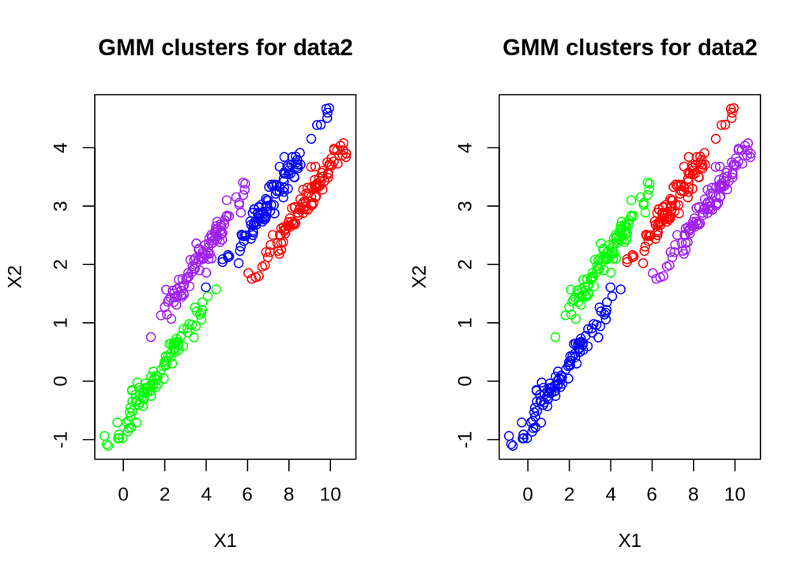

```r
par(mfrow = c(1, 2))
plot(data2$X1, data2$X2, col=c("red", "green", "blue", "purple")[GMM.data2$classification], xlab = "X1", ylab = "X2", main = "GMM clusters for data2")
plot(data2$X1, data2$X2, col=c("red", "green", "blue", "purple")[data2$truth], xlab = "X1", ylab = "X2", main = "GMM clusters for data2")
```

**5.** Let’s take a look at the summary of the GMM fitted for `data2`

```r
summary(GMM.data2)
```

```
## ----------------------------------------------------
## Gaussian finite mixture model fitted by EM algorithm
## ----------------------------------------------------
##
## Mclust EEE (ellipsoidal, equal volume, shape and orientation) model with 4
## components:
##
##  log.likelihood   n df       BIC       ICL
##       -938.8639 400 14 -1961.608 -1965.709
##
## Clustering table:
##   1   2   3   4
## 100  99 101 100
```

**6.** Following is a series of plots obtained from the GMM :

- This plot shows how the data was classified by the GMM

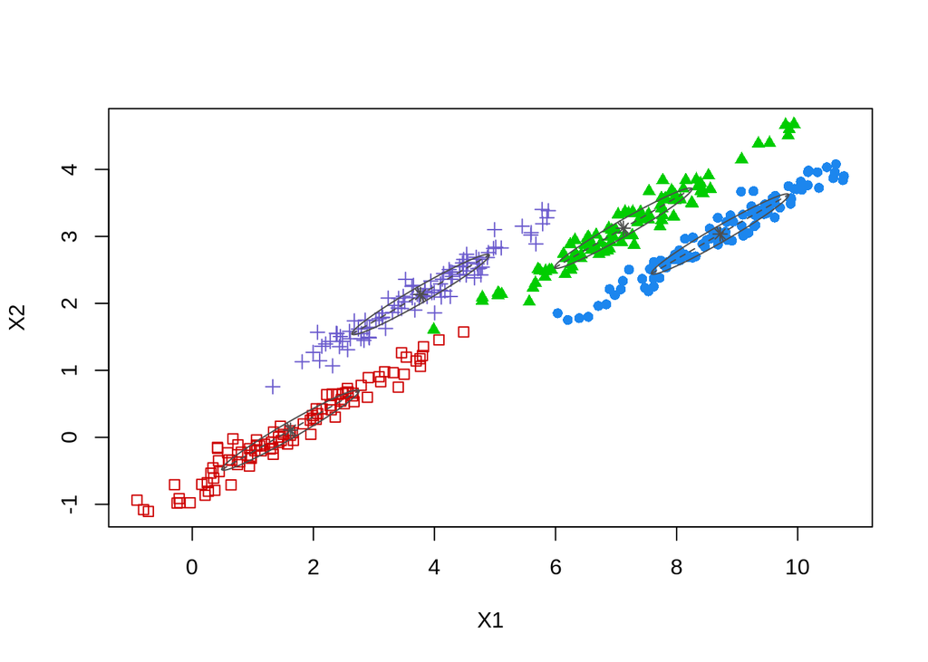

```r
plot(GMM.data2, what = "classification")
```

- This plot shows the uncertainty computed for each point. The bigger the point, the bigger the uncertainty it actually belongs to the class.

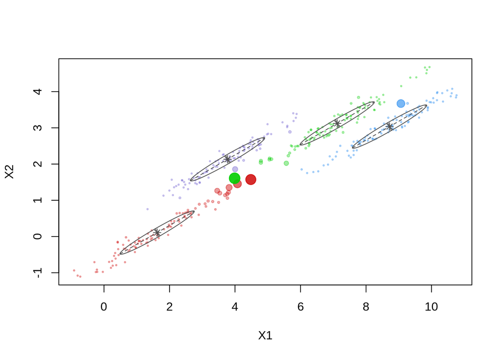

```r
plot(GMM.data2, what = "uncertainty")
```